# Script for ‘Assessing Daily Life Activities with Experience Sampling Methodology (ESM): Scoring Predefined Categories or Qualitative Analysis of Open-Ended Responses?’ - PART 1 - Differences between open-ended responses and categorical items

Marie Stadel

2024-09-10

# 0. Packages & data

```r
library(tidyverse) # Data handling
library(knitr) # For report
library(eulerr) # For nice Venn diagrams
library(eatATA) # for dummies to factor function
library(wordcloud)
library(wordcloud2)
library(RColorBrewer)
```

Raw activity data from both samples:

```r
act <-  read.csv('activities_all.csv',
                 row.names = NULL)
```

# 1. Quality of open-ended responses (word count across the study period)

The word count was determined in LIWC, so I use the export file:

```r
# results from liwc original dataset each observation separate
liwc <- read.csv('LIWC-22 Results - activities_all - LIWC Analysis.csv',
                 row.names = NULL)
```

Here some descriptives for the overall word count in the open responses:

```r
liwc %>% group_by(sample) %>% summarise(
  meanWC = mean(WC),
  sdWC = sd(WC),
  minWC = min(WC),
  maxWC = max(WC),
  N = n()) -> WC.des

kable(WC.des)
```

| sample | meanWC | sdWC | minWC | maxWC | N |
| --- | --- | --- | --- | --- | --- |
| 1 | 7.265811 | 6.832828 | 1 | 77 | 3194 |
| 2 | 8.938748 | 8.000820 | 1 | 82 | 2253 |

Against our expectation, the average word count per observation per sample is larger in sample 2 (9 words per observation) than in sample 1 (7 words per observation)

Here the distribution:

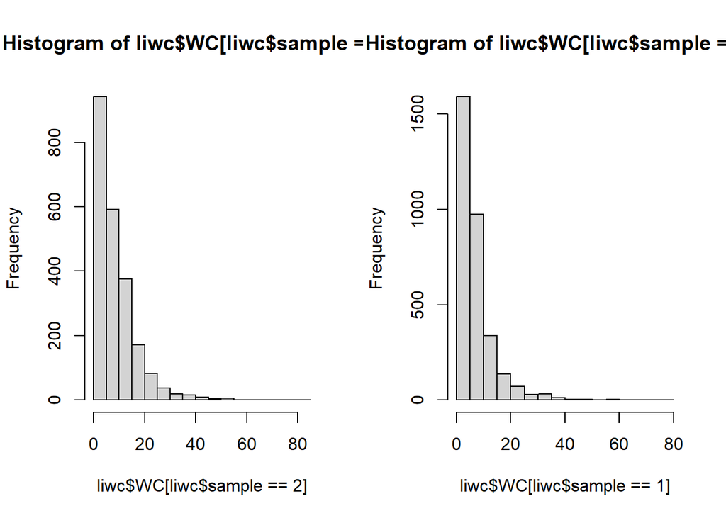

```r
par(mfrow=c(1,2))
hist(liwc$WC[liwc$sample==2])
hist(liwc$WC[liwc$sample==1])
```

Here average word count per study week per sample (i.e. did participants get less motivated to fill in the open text box responses?)

Add study week (1-4) and study day (1-28) variables. This is not the same for each participant.

```r
liwc %>% filter(sample == 1) -> liwc1
liwc %>% filter(sample == 2) -> liwc2

## Sample 1
liwc1$date <- date(liwc1$timeStampStop)

liwc1 %>% filter(ppID %in% c(102:199)) -> SONA # SONA groups
liwc1 %>% filter(ppID %in% c(203,213,215,208)) -> PPP1
liwc1 %>% filter(ppID %in% c(204,201,207,209,212,214,217,216)) -> PPP2

# SONA groups
between(SONA$date, mdy('October 25th, 2021'), mdy('November 2nd, 2021')) -> SONA$w1
between(SONA$date, mdy('November 3rd, 2021'), mdy('November 9th, 2021')) -> SONA$w2
between(SONA$date, mdy('November 10th, 2021'), mdy('November 16th, 2021')) -> SONA$w3
between(SONA$date, mdy('November 17th, 2021'), mdy('November 23rd, 2021')) -> SONA$w4
SONA$study.day <- as.numeric(SONA$date - mdy('October 25th, 2021'))

between(PPP1$date, mdy('November 3rd, 2021'), mdy('November 9th, 2021')) -> PPP1$w1
between(PPP1$date, mdy('November 10th, 2021'), mdy('November 16th, 2021')) -> PPP1$w2
between(PPP1$date, mdy('November 17th, 2021'), mdy('November 23rd, 2021')) -> PPP1$w3
between(PPP1$date, mdy('November 24th, 2021'), mdy('December 1st, 2021')) -> PPP1$w4
PPP1$study.day <- as.numeric(PPP1$date - mdy('November 2nd, 2021'))

between(PPP2$date, mdy('November 4th, 2021'), mdy('November 10th, 2021')) -> PPP2$w1
between(PPP2$date, mdy('November 11th, 2021'), mdy('November 17th, 2021')) -> PPP2$w2
between(PPP2$date, mdy('November 18th, 2021'), mdy('November 23rd, 2021')) -> PPP2$w3
between(PPP2$date, mdy('November 24th, 2021'), mdy('December 2nd, 2021')) -> PPP2$w4
PPP2$study.day <- as.numeric(PPP2$date - mdy('November 3rd, 2021'))

SONA <- dummiesToFactor(SONA, dummies = c("w1", "w2", "w3","w4"), facVar = "study.week")
PPP1 <- dummiesToFactor(PPP1, dummies = c("w1", "w2", "w3","w4"), facVar = "study.week")
PPP2 <- dummiesToFactor(PPP2, dummies = c("w1", "w2", "w3","w4"), facVar = "study.week")
liwc1 <- rbind(SONA, PPP1)
liwc1<- rbind(liwc1, PPP2)
PPP <- rbind(PPP1, PPP2)

liwc1 %>% arrange(ppID, timeStampStart) -> liwc1

rm(SONA,PPP1,PPP2)

## Sample 2
liwc2$date <- date(liwc2$timeStampStop)
between(liwc2$date, mdy('October 17th, 2022'), mdy('October 24th, 2022')) -> liwc2$w1
between(liwc2$date, mdy('October 25th, 2022'), mdy('October 31st, 2022')) -> liwc2$w2
between(liwc2$date, mdy('November 1st, 2022'), mdy('November 7th, 2022')) -> liwc2$w3
between(liwc2$date, mdy('November 8th, 2022'), mdy('November 15th, 2022')) -> liwc2$w4
liwc2$study.day <- as.numeric(liwc2$date - mdy('October 17th, 2022'))
liwc2 <- dummiesToFactor(liwc2, dummies = c("w1", "w2", "w3","w4"), facVar = "study.week")

liwc2 %>% arrange(ppID, timeStampStart) -> liwc2
```

Word count over time per single participant:

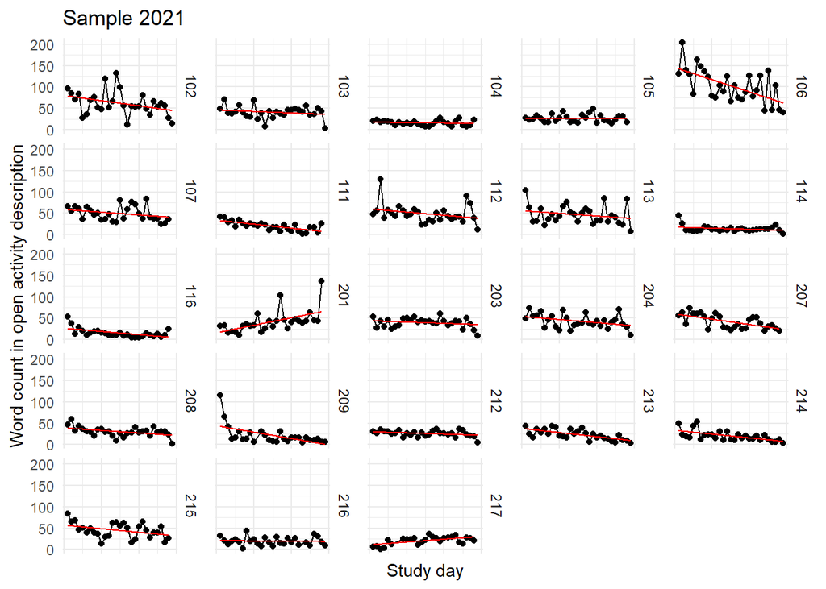

```r
liwc1 %>%
  group_by(ppID,study.day) %>%
  summarize(total.day.wc = sum(WC)) -> liwc1.daycount

liwc2 %>%
  group_by(ppID,study.day) %>%
  summarize(total.day.wc = sum(WC)) -> liwc2.daycount

ggplot(liwc1.daycount, aes(x=study.day,
                  y=total.day.wc)) + geom_point() +
  geom_line() + theme_minimal() + theme(axis.text.x = element_blank(),
    axis.ticks.x = element_blank()) + xlab('Study day') + ggtitle('Sample 2021') +
  ylab('Word count in open activity description') +
 geom_smooth(method='lm', formula= y~x, color='red',size = 0.5, se=FALSE) +
  facet_wrap(~ as.factor(ppID), ncol=5, strip.position = "right")
```

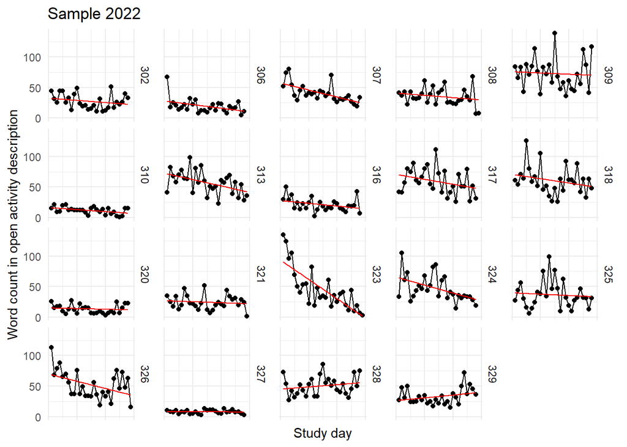

```r
ggplot(liwc2.daycount, aes(x=study.day,
                  y=total.day.wc)) + geom_point() +
  geom_line() + theme_minimal() + theme(axis.text.x = element_blank(),
    axis.ticks.x = element_blank()) + xlab('Study day') + ggtitle('Sample 2022') +
  ylab('Word count in open activity description') +
 geom_smooth(method='lm', formula= y~x, color='red', size = 0.5, se=FALSE) +
  facet_wrap(~ as.factor(ppID), ncol=5, strip.position = "right")
```

All participants of one sample in one plot:

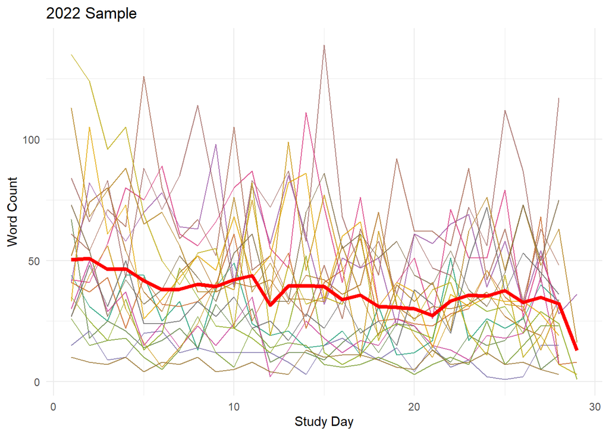

```r
# Generate a distinct color palette using ColorBrewer
n <- length(unique(liwc2.daycount$ppID)) # Number of unique participants
palette <- brewer.pal(min(n, 8), "Dark2") # Use "Dark2" palette which has up to 8 colors
if (n > 8) {
  # If more than 8 participants, repeat the palette
  palette <- colorRampPalette(palette)(n)
}

liwc2.daycount$ppID <- as.factor(liwc2.daycount$ppID)

# Create the plot
ggplot(liwc2.daycount, aes(x = study.day, y = total.day.wc, group = ppID, color = ppID)) +
  geom_line(alpha = 0.8) + # Line plot for each participant
  scale_color_manual(values = palette) + # Apply the custom color palette
  stat_summary(aes(group = 1), fun = mean, geom = "line", color = "red", size = 1.5) + # Red line for average
  theme_minimal() + # Minimal theme
  labs(
    title = "2022 Sample",
    x = "Study Day",
    y = "Word Count"
  ) +
  theme(legend.position = "none") # Remove the legend
```

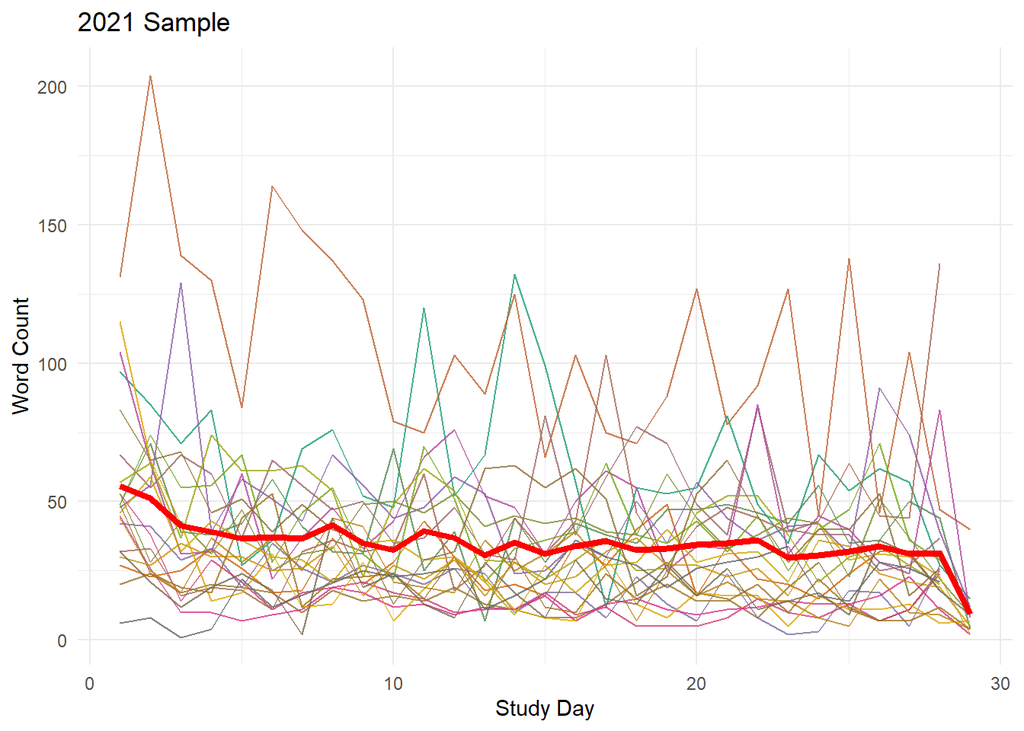

```r
# Generate a distinct color palette using ColorBrewer
n <- length(unique(liwc1.daycount$ppID)) # Number of unique participants
palette <- brewer.pal(min(n, 8), "Dark2") # Use "Dark2" palette which has up to 8 colors
if (n > 8) {
  # If more than 8 participants, repeat the palette
  palette <- colorRampPalette(palette)(n)
}
liwc1.daycount$ppID <- as.factor(liwc1.daycount$ppID)

# Create the plot
ggplot(liwc1.daycount, aes(x = study.day, y = total.day.wc, group = ppID, color = ppID)) +
  geom_line(alpha = 0.8) + # Line plot for each participant
  scale_color_manual(values = palette) + # Apply the custom color palette
  stat_summary(aes(group = 1), fun = mean, geom = "line", color = "red", size = 1.5) + # Red line for average
  theme_minimal() + # Minimal theme
  labs(
    title = "2021 Sample",
    x = "Study Day",
    y = "Word Count"
  ) +
  theme(legend.position = "none") # Remove the legend
```

# 2. Impact of the categorical item on open-ended responses

## 2.1 Lexical Diversity

We look at lexical diversity, specifically type token ratio (TTR). TTR was determined with BUTTER, so we use this output file here.

```r
butter.all <- read.csv('BUTTER_Lexical Richness_activities_all_per sample.csv',
                 row.names = NULL)

butter.all %>% select(Tokens, Types, TTR) %>%
  mutate(Sample = c(2,1)) -> butter.all.results

kable(butter.all.results)
```

| Tokens | Types | TTR | Sample |
| --- | --- | --- | --- |
| 7796 | 995 | 0.1276296 | 2 |
| 8923 | 1028 | 0.1152079 | 1 |

## 2.2 Assimilation to multiple choice wording

Here I want to see if the words from the MC categories occur more often in the open text descriptions (i.e. does the wording of participants assimilate to the category labels (over time)?)

The MC item was only used in sample 2, so we only need data from that sample

```r
MC.wcounts <- read.csv('activities_sample2_open_keyword_output.csv',
                 row.names = NULL)
# the loaded file is obtained via the Python script match_activity_keywords.py
```

Plot the number of occurences per activity category across time. For this I need to aggregate the presence/absence data

Add study day variable (1 to 28) and beep variable:

```r
MC.wcounts$date <- date(MC.wcounts$stop)
MC.wcounts %>% mutate(studyday = match(date, unique(date))) -> MC.wcounts
# Note that some participants filled in their last beep after midnight (= day 29)

MC.wcounts %>%
  group_by(PPID) %>% mutate(beep = match(stop, unique(stop))) -> MC.wcounts
```

Summarize word counts per study day.

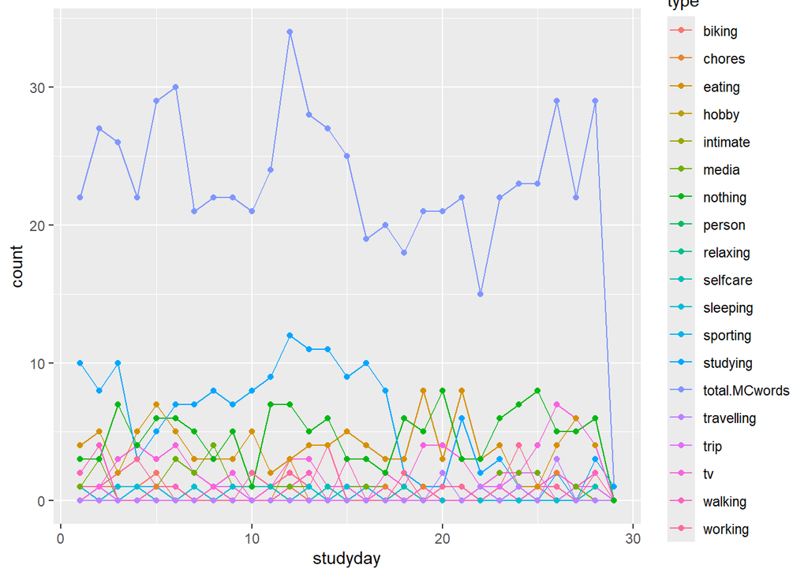

```r
MC.wcounts %>%
  group_by(studyday) %>%
  summarize(
    total.MCwords = sum(total),
    studying = sum(studying),
    working = sum(working),
    sporting = sum(sporting),
    walking = sum(walking),
    biking =sum(biking),
    hobby = sum(hobby),
    trip = sum(trip),
    tv = sum(tv),
    media = sum(media),
    person = sum(person),
    intimate = sum(intimate),
    chores = sum(chores),
    selfcare = sum(selfcare),
    eating = sum(eating),
    relaxing = sum(relaxingnothing),
    sleeping = sum(sleeping),
    travelling = sum(travelling),
    nothing = sum(nothing)) -> MC.wcounts.pday


MC.wcounts.pday_long <- gather(MC.wcounts.pday, type, count, total.MCwords:nothing)

ggplot(data=MC.wcounts.pday_long, aes(x=studyday, y=count, group = type, colour = type)) +
  geom_line()+
  geom_point()
```

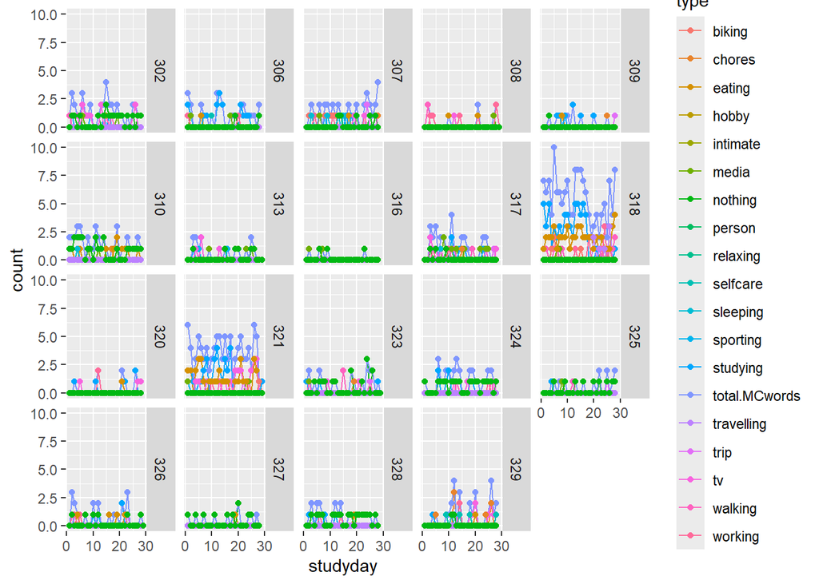

```r
MC.wcounts %>%
  group_by(PPID,studyday) %>%
  summarize(
    total.MCwords = sum(total, na.rm = T),
    studying = sum(studying, na.rm = T),
    working = sum(working, na.rm = T),
    sporting = sum(sporting, na.rm = T),
    walking = sum(walking, na.rm = T),
    biking =sum(biking, na.rm = T),
    hobby = sum(hobby, na.rm = T),
    trip = sum(trip, na.rm = T),
    tv = sum(tv, na.rm = T),
    media = sum(media, na.rm = T),
    person = sum(person, na.rm = T),
    intimate = sum(intimate, na.rm = T),
    chores = sum(chores, na.rm = T),
    selfcare = sum(selfcare, na.rm = T),
    eating = sum(eating, na.rm = T),
    relaxing = sum(relaxingnothing, na.rm = T),
    sleeping = sum(sleeping, na.rm = T),
    travelling = sum(travelling, na.rm = T),
    nothing = sum(nothing, na.rm = T)) -> MC.wcounts.pday.pp.count

MC.wcounts.pday.pp_long.count <- gather(MC.wcounts.pday.pp.count, type, count, total.MCwords:nothing)

ggplot(data=MC.wcounts.pday.pp_long.count, aes(x=studyday, y=count, group = type, colour = type)) +
  geom_line()+
  geom_point()  +
  facet_wrap(~ as.factor(PPID), ncol=5, strip.position = "right")
```

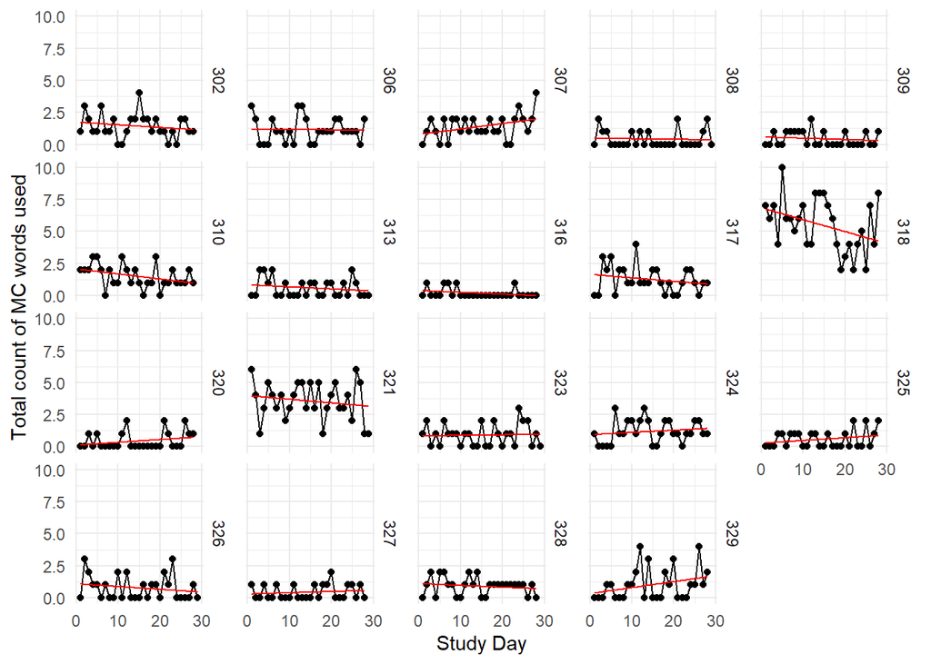

```r
MC.wcounts.pday.pp_long.count %>% filter(type == "total.MCwords") -> only.total

ggplot(data=only.total, aes(x=studyday, y=count)) +
  geom_line()+
  geom_point()  + theme_minimal() + xlab('Study Day') + ylab('Total count of MC words used') +
 geom_smooth(method='lm', formula= y~x, color='red', size = 0.5, se=FALSE) +
  facet_wrap(~ as.factor(PPID), ncol=5, strip.position = "right")
```

# 3. Describing vocabularies across samples and comparing response formats within the 2022 sample

We counted how often each word occured in: 1) the mc responses 2) open text responses sample 1 3) open text responses sample 2

This allowed us to quantify content overlap between the three and explore where they do not overlap.

```r
wcounts <- read.csv('activities_unique_output_SUMMARY.csv',
                 row.names = NULL)
# the loaded file is obtained via the Python script count_unique_activity_words.py
```

Formatting

```r
wcounts.t <- wcounts[1,-c(1,3,5)] # first row contains total, columns with words can be omitted
wcounts <- wcounts[-1,] # remove total from overall df

# format each data source on its own
wcounts[, 1:2] %>% rename(word = X, S1_open = X1_open) %>% arrange(desc(S1_open)) -> wcounts.S1open
wcounts[, 3:4] %>% rename(word = X.1, S2_open = X2_open) %>% arrange(desc(S2_open)) -> wcounts.S2open
wcounts[, 5:6] %>% rename(word = X.2,  S2_MC = X2_mc) %>% arrange(desc(S2_MC)) -> wcounts.S2mc

# combine into one df with the right format:
wcounts <- full_join(wcounts.S1open, wcounts.S2open, by = 'word')
wcounts <- full_join(wcounts, wcounts.S2mc, by = 'word')
```

## 3.1 Check word frequencies per data scource

Most frequently used words (Top 10)

```r
head(wcounts.S1open , 10)
```

```
##         word S1_open
## 1  breakfast     364
## 2    watched     338
## 3     dinner     330
## 4    studied     291
## 5   studying     290
## 6        ate     289
## 7      lunch     210
## 8      study     140
## 9     friend     133
## 10  watching     132
```

```r
head(wcounts.S2open , 10)
```

```
##         word S2_open
## 1    studied     228
## 2     dinner     209
## 3    watched     208
## 4  breakfast     187
## 5   studying     165
## 6        ate     153
## 7    nothing     138
## 8      lunch     138
## 9  boyfriend     134
## 10       bed     130
```

```r
head(wcounts.S2mc , 13) # some words come from the same category, so here we look at top 13
```

```
##           word S2_MC
## 1       eating  1001
## 2       person   929
## 3     studying   658
## 4       social   493
## 5        media   493
## 6  consumption   493
## 7       biking   461
## 8     relaxing   417
## 9       chores   346
## 10   household   346
## 11    selfcare   299
## 12    watching   281
## 13     walking   270
```

## 3.2 Venn diagrams for proportion of overlap

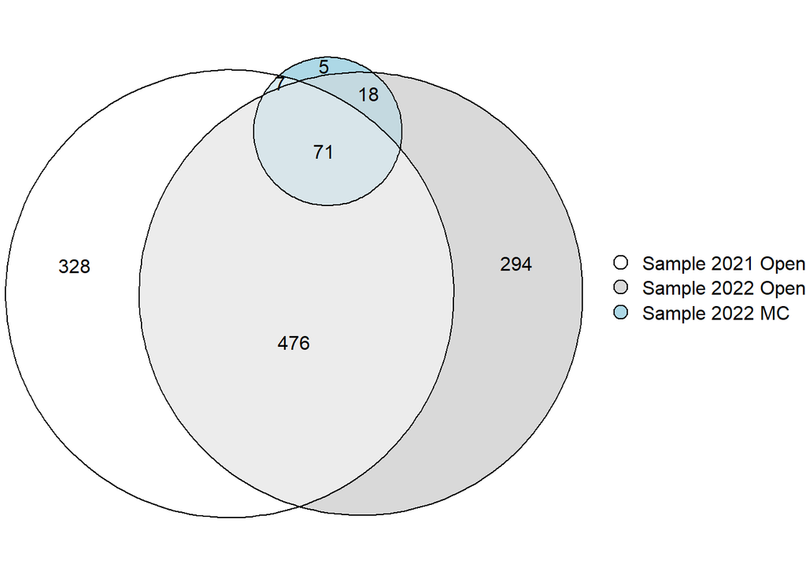

```r
# Create binary columns based on counts being greater than zero
wcounts$S1_open_unique <- ifelse(wcounts$S1_open > 0, 1, 0)
wcounts$S2_open_unique <- ifelse(wcounts$S2_open > 0, 1, 0)
wcounts$S2_MC_unique <- ifelse(wcounts$S2_MC > 0, 1, 0)

mat <- cbind(
  S1_open = wcounts$S1_open_unique,
  S2_open = wcounts$S2_open_unique,
  S2_MC = wcounts$S2_MC_unique)

wordoverlapp_plot <- euler(mat)
plot(wordoverlapp_plot,
     quantities = TRUE,
     legend = list(labels = c('Sample 2021 Open',
                              'Sample 2022 Open',
                              'Sample 2022 MC')))
```

We can see that the words used in the MC categories overlap a bit more with sample 2 than with sample 1.

## 3.3 Check words unique to each category

15 most frequently used unique words

```r
wcounts %>% filter(S2_MC_unique == 1 & S2_open_unique == 0 & S1_open_unique == 0) -> only_MC
only_MC %>% select(word, S2_MC) %>% arrange(desc(S2_MC)) %>% head(.,15) %>% kable()
```

| word | S2_MC |
| --- | --- |
| engaging | 245 |
| intimate | 36 |
| topics | 9 |
| interesting | 9 |
| laptops | 2 |

```r
wcounts %>% filter(S2_MC_unique == 0 & S2_open_unique == 1 & S1_open_unique == 0) -> only_S2open
only_S2open %>% select(word, S2_open) %>% arrange(desc(S2_open)) %>% head(.,15) %>% kable()
```

| word | S2_open |
| --- | --- |
| routine | 28 |
| birds | 24 |
| skincare | 24 |
| typing | 24 |
| female | 16 |
| bath | 15 |
| videocall | 13 |
| bouldering | 13 |
| american | 11 |
| climbing | 10 |
| hockey | 9 |
| flatmates | 8 |
| meal | 8 |
| paris | 8 |
| garbage | 7 |

```r
wcounts %>% filter(S2_MC_unique == 0 & S2_open_unique == 0 & S1_open_unique == 1) -> only_S1open
only_S1open %>% select(word, S1_open) %>% arrange(desc(S1_open)) %>% head(.,15) %>% kable()
```

| word | S1_open |
| --- | --- |
| submission | 30 |
| learning | 25 |
| episode | 25 |
| sinterklaas | 20 |
| crochet | 16 |
| patients | 16 |
| painted | 14 |
| introduction | 12 |
| puzzle | 11 |
| office | 11 |
| exercises | 10 |
| hamburg | 10 |
| history | 10 |
| copenhagen | 9 |
| practicals | 9 |

Wordclouds unique open-ended description words:

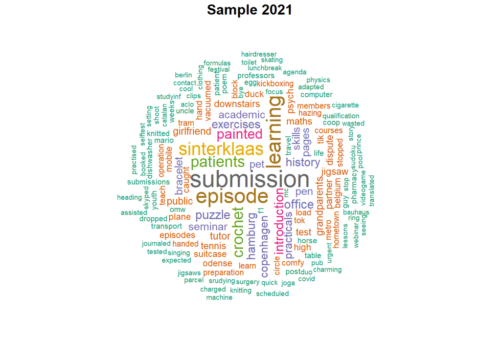

```r
set.seed(46)
par(mar = c(0, 0, 0, 0))
wordcloud(only_S1open$word, only_S1open$S1_open,
                    min.freq = 2, max.words = 150, scale=c(2, .5),
                    random.order=FALSE, rot.per=.30, colors=brewer.pal(8, "Dark2"))
title(main="Sample 2021", line = -1)
```

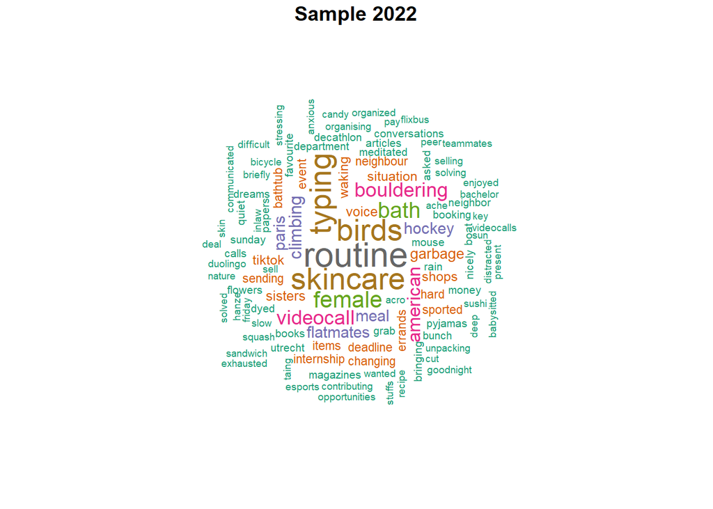

```r
par(mar = c(0, 0, 0, 0))
wordcloud(only_S2open$word, only_S2open$S2_open,
                    min.freq = 2, max.words = 150, scale=c(2, .5),
                    random.order=FALSE, rot.per=.30, colors=brewer.pal(8, "Dark2"))
title(main="Sample 2022", line = -1)
```

## 3.4 Comparing position of multiple choice and open response in semantic space

Katie determined the position in semantic space of each text and MC response (as a vector) and then computed Cosine similarity of these vectors. Here I load the results from this:

```r
distance <- read.csv('activities_sample2_distances.csv',
                 row.names = NULL)
# the loaded file is obtained via the Python script compare_word_embeddings.ipynb
```

Overview

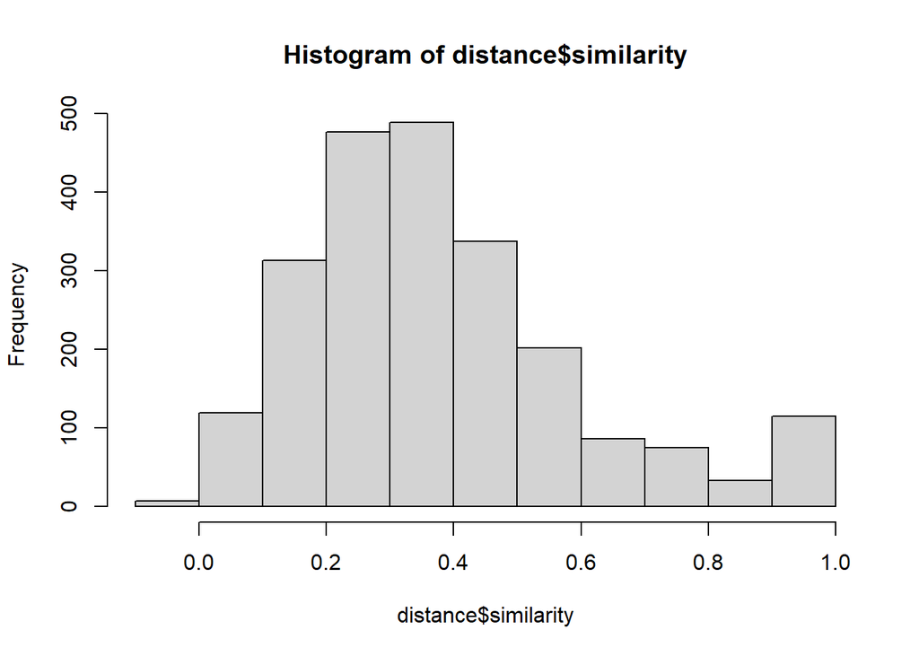

```r
hist(distance$similarity)
```

Descriptives

```r
distance %>%
  summarise(
    mean.sim = mean(similarity),
    sd.sim = sd(similarity),
    min.sim = min(similarity),
    max.sim = max(similarity)) -> dist.des

kable(dist.des)
```

| mean.sim | sd.sim | min.sim | max.sim |
| --- | --- | --- | --- |
| 0.3811299 | 0.2215967 | -0.0436042 | 1 |

Extract observations with low similarity

Based on percentile (lowest/highest 10%)

```r
distance %>% filter(quantile(similarity, 0.1) > similarity) %>%
  arrange(.,similarity)-> low.sim
```

Extract observations with max similarity

```r
distance %>% filter(similarity == 1) -> matches
nrow(matches)
```

```
## [1] 74
```

```r
unique(matches$activity_open)
```

```
## [1] "nothing"           "relaxing"          "working"
## [4] "talking w friends" "-"                 "studying"
```

# 4. Exploring responses via the multiple choice item and participant-defined categories

```r
act <-  read.csv('activities_sample2.csv',
                 row.names = NULL)
```

## 4.1 Base Categories

These are all the base categories

```r
basecat <- c('studying', 'working',  'sporting', 'walking', 'biking',
'engaging in a hobby','trip / organised activity', 'watching TV',
'social media consumption', 'being with another person',
'something intimate', 'household chores','self-care',
'eating', 'relaxing/nothing', 'sleeping', 'travelling', 'nothing')
```

I would like to look at how often each category was selected. Currently, the dataset contains one variable with all selected choices, each choice separated by a comma.

Now, I first reformat this so that I have one variable per case category.

```r
act[basecat] <- NA # add new variables, one for each base category
y <- 8 # variable 8 is the first one of the new ones = start value for loop

for (cat in basecat) { # now loop for each base category
  for (row in 1:length(act$activity_mc)){ # through every row
    if(is.na(str_extract(act[row,5],cat))){ # check if the string contains the category
      act[row,y] <- F                 # label presence or absence in the variable
    } else{
      act[row,y] <- T
    }
  }
  y <- y+1 # after one category is done, we switch to the next variable
}
```

Sample-level descriptives

```r
act %>% summarise(
  studying = sum(studying),
  working = sum(working),
  sporting = sum(sporting),
  walking = sum(walking),
  biking = sum(biking),
  hobby = sum(`engaging in a hobby`),
  trip = sum(`trip / organised activity`),
  TV = sum(`watching TV`),
  social.media = sum(`social media consumption`),
  being.with = sum(`being with another person`),
  intimate = sum(`something intimate`),
  household = sum(`household chores`),
  self.care = sum(`self-care`),
  eating = sum(eating),
  relaxing.nothing = sum(`relaxing/nothing`),
  sleeping = sum(sleeping),
  travelling = sum(travelling),
  nothing = sum(nothing)) -> sample.des

kable(sample.des)
```

| studying | working | sporting | walking | biking | hobby | trip | TV | social.media | being.with | intimate | household | self.care | eating | relaxing.nothing | sleeping | travelling | nothing |
| --- | --- | --- | --- | --- | --- | --- | --- | --- | --- | --- | --- | --- | --- | --- | --- | --- | --- |
| 658 | 157 | 72 | 268 | 461 | 245 | 24 | 243 | 493 | 929 | 36 | 346 | 299 | 1001 | 232 | 201 | 92 | 410 |

Plot

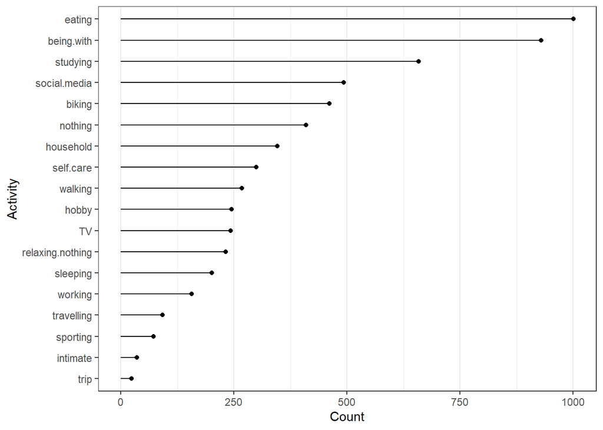

```r
sample.des_long <- gather(sample.des, activity, count, studying:nothing, factor_key=TRUE)

ggplot(sample.des_long, aes(y= reorder(activity, count),
                            yend = activity,
                            x= count,
                            xend = 0)) +
  geom_segment() + geom_point() + theme_bw() +
  theme(panel.grid.major.y = element_blank()) +
   xlab("Count") + ylab("Activity")
```

Now participant-level descriptives

```r
act %>% group_by(ppID) %>%
  summarise(
  studying = sum(studying),
  working = sum(working),
  sporting = sum(sporting),
  walking = sum(walking),
  biking = sum(biking),
  hobby = sum(`engaging in a hobby`),
  trip = sum(`trip / organised activity`),
  TV = sum(`watching TV`),
  social.media = sum(`social media consumption`),
  being.with = sum(`being with another person`),
  intimate = sum(`something intimate`),
  household = sum(`household chores`),
  self.care = sum(`self-care`),
  eating = sum(eating),
  relaxing.nothing = sum(`relaxing/nothing`),
  sleeping = sum(sleeping),
  travelling = sum(travelling),
  nothing = sum(nothing)) -> pp.des

kable(pp.des)
```

| ppID | studying | working | sporting | walking | biking | hobby | trip | TV | social.media | being.with | intimate | household | self.care | eating | relaxing.nothing | sleeping | travelling | nothing |
| --- | --- | --- | --- | --- | --- | --- | --- | --- | --- | --- | --- | --- | --- | --- | --- | --- | --- | --- |
| 302 | 31 | 10 | 2 | 17 | 31 | 17 | 1 | 0 | 14 | 24 | 0 | 11 | 12 | 46 | 12 | 9 | 3 | 36 |
| 306 | 47 | 15 | 2 | 6 | 33 | 7 | 3 | 3 | 66 | 38 | 2 | 7 | 10 | 69 | 16 | 0 | 2 | 20 |
| 307 | 36 | 0 | 2 | 1 | 10 | 6 | 6 | 10 | 7 | 8 | 1 | 16 | 10 | 0 | 3 | 8 | 5 | 6 |
| 308 | 17 | 19 | 6 | 9 | 40 | 0 | 2 | 20 | 4 | 56 | 0 | 8 | 17 | 32 | 2 | 21 | 19 | 3 |
| 309 | 42 | 0 | 1 | 17 | 25 | 0 | 0 | 58 | 19 | 64 | 5 | 24 | 41 | 79 | 42 | 5 | 3 | 47 |
| 310 | 1 | 0 | 0 | 0 | 0 | 33 | 0 | 3 | 5 | 0 | 1 | 12 | 3 | 17 | 2 | 13 | 0 | 21 |
| 313 | 27 | 12 | 17 | 22 | 56 | 30 | 2 | 19 | 39 | 96 | 4 | 13 | 31 | 80 | 43 | 12 | 9 | 55 |
| 316 | 37 | 17 | 2 | 44 | 16 | 6 | 0 | 0 | 31 | 96 | 4 | 14 | 13 | 58 | 1 | 8 | 6 | 2 |
| 317 | 30 | 4 | 0 | 25 | 8 | 3 | 0 | 19 | 34 | 22 | 1 | 18 | 8 | 63 | 2 | 9 | 7 | 11 |
| 318 | 65 | 7 | 9 | 17 | 45 | 31 | 0 | 0 | 18 | 21 | 1 | 60 | 23 | 72 | 7 | 12 | 19 | 12 |
| 320 | 33 | 12 | 3 | 0 | 0 | 11 | 0 | 4 | 0 | 107 | 0 | 7 | 4 | 4 | 0 | 15 | 0 | 0 |
| 321 | 38 | 6 | 7 | 7 | 32 | 0 | 4 | 24 | 49 | 120 | 0 | 9 | 9 | 72 | 11 | 26 | 0 | 17 |
| 323 | 11 | 5 | 3 | 9 | 29 | 9 | 3 | 9 | 34 | 49 | 4 | 8 | 5 | 49 | 2 | 25 | 2 | 8 |
| 324 | 58 | 1 | 1 | 10 | 33 | 2 | 0 | 16 | 7 | 37 | 0 | 2 | 6 | 47 | 1 | 2 | 2 | 29 |
| 325 | 50 | 0 | 1 | 5 | 22 | 6 | 1 | 12 | 34 | 26 | 3 | 17 | 5 | 51 | 28 | 10 | 2 | 36 |
| 326 | 42 | 23 | 9 | 37 | 0 | 4 | 0 | 6 | 27 | 23 | 0 | 20 | 42 | 71 | 16 | 7 | 8 | 28 |
| 327 | 29 | 2 | 0 | 1 | 2 | 10 | 1 | 17 | 5 | 11 | 8 | 17 | 7 | 39 | 10 | 5 | 5 | 18 |
| 328 | 53 | 1 | 0 | 16 | 41 | 65 | 0 | 5 | 56 | 47 | 2 | 38 | 31 | 74 | 15 | 3 | 0 | 34 |
| 329 | 11 | 23 | 7 | 25 | 38 | 5 | 1 | 18 | 44 | 84 | 0 | 45 | 22 | 78 | 19 | 11 | 0 | 27 |

Plot

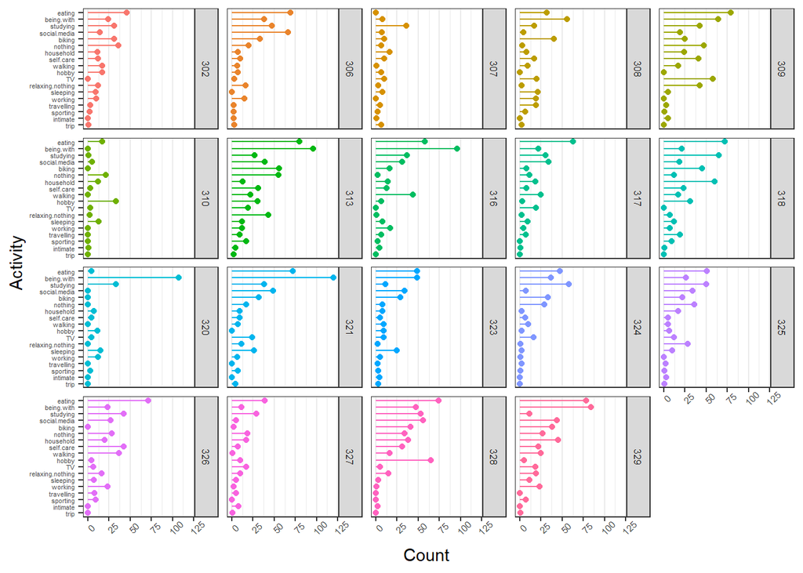

```r
pp.des_long <- gather(pp.des, activity, count, studying:nothing, factor_key=TRUE)

ggplot(pp.des_long, aes(y= reorder(activity, count),
                        yend = activity,
                        x= count,
                        xend = 0,
                        color = as.factor(ppID))) +
  geom_segment() + geom_point() + theme_bw() +
  theme(panel.grid.major.y = element_blank()) +
   xlab("Count") + ylab("Activity") +
  facet_wrap(~ ppID, ncol=5, strip.position = "right") +
  theme(legend.position = "none") +
  theme(axis.text.x = element_text(size = 6, angle = 45),
        axis.text.y = element_text(size = 4))+
  theme(strip.text.y = element_text(size = 6))
```

## 4.2 Personalised Categories

To obtain the personalised categories, I filter out all the base category responses + the separation comma and save the remaining part of the string in a new variable

```r
# Define a list of standard categories
base.cat <- c('studying', 'working', 'sporting', 'walking', 'biking',
              'engaging in a hobby', 'trip / organised activity',
              'watching TV', 'social media consumption',
              'being with another person', 'something intimate',
              'household chores', 'self-care', 'eating', 'relaxing/nothing',
              'relaxing','sleeping', 'travelling', 'nothing')

# Step 1: Split each string by commas and trim whitespace
act<- act %>%
  mutate(activity_list = str_split(act$activity_mc, ",") %>% map(~str_trim(.)))

# Step 2: Filter out the standard categories
act<- act %>%
  mutate(personal.cat = map(activity_list, ~setdiff(.x, base.cat))) %>%
  mutate(personal.cat = map(personal.cat, ~.x[.x != ""]))  # Remove empty elements

# Step 3: Filter out rows where personal.cat is empty
act.personal <- act %>%
  filter(lengths(personal.cat) > 0) %>%
  filter(!map_lgl(personal.cat, ~any(. == "-" | is.na(.))))  # Exclude "-" and NA

nrow(act.personal) # number of times personalised categories were used
```

```
## [1] 687
```

Now I identify unique personalised categories and save them as an object which also contains frequencies of use

```r
unnested.act.personal <- act.personal %>%
  select(ppID, personal.cat) %>%
  unnest(personal.cat)

summary.act.personal <- unnested.act.personal %>%
  group_by(personal.cat) %>%
  summarise(
    frequency = n(),                 # Count the frequency of each custom activity
    participant_ids = paste(unique(ppID), collapse = ",")  # Combine participant IDs into a single string
  )

write_csv(summary.act.personal, "summary.act.personal.csv")

summary.act.personal %>%
  kable(format = "pipe", align = 'c', col.names = c("Activity", "Frequency", "Participant IDs"))
```

| Activity | Frequency | Participant IDs |
| --- | --- | --- |
| (grocery) shopping | 7 | 306 |
| Lecture | 6 | 317 |
| SONA study | 1 | 324 |
| Taking exam | 2 | 321 |
| audiobook | 9 | 309 |
| babysitting the dog | 2 | 308 |
| baking | 1 | 321 |
| birthday party | 2 | 308 |
| browsing the internet | 14 | 306 |
| browsing the internet for laptops | 2 | 306 |
| building | 2 | 308 |
| calling/video calling | 25 | 309 |
| celebrating Halloween | 2 | 316 |
| class | 2 | 325 |
| committee meeting | 4 | 309 |
| communicating | 52 | 318 |
| concert | 1 | 308 |
| cooking | 99 | 308,309,310,321,323,324,325 |
| cuddling | 27 | 309 |
| dancing | 1 | 316 |
| dog walking | 16 | 302 |
| doing research on the internet about interesting topics | 9 | 309 |
| drinking | 3 | 309 |
| drinking coffee | 42 | 316 |
| driving on a motor | 1 | 308 |
| eat | 4 | 320 |
| exam | 2 | 325 |
| financial stuff | 4 | 310 |
| fixing up stuff | 2 | 324 |
| following a lecture | 7 | 306 |
| getting ready | 39 | 329 |
| going out | 4 | 308 |
| going to a GP | 1 | 321 |
| going to a lecture | 7 | 309 |
| going to a party | 2 | 324 |
| going to the cinema | 1 | 308 |
| going to the museum | 1 | 316 |
| groceries | 12 | 329 |
| had a class | 9 | 329 |
| had a meeting | 8 | 306 |
| having an argument | 1 | 321 |
| improv | 1 | 316 |
| in class | 1 | 325 |
| joining an information session | 1 | 321 |
| jop application | 22 | 310 |
| jop applications | 3 | 310 |
| k | 1 | 310 |
| listening music | 4 | 317 |
| listening to a podcast | 11 | 316 |
| making a call | 9 | 316 |
| master | 1 | 320 |
| meditating | 18 | 309 |
| meeting | 5 | 321,324,329 |
| movie | 3 | 316 |
| on a long call | 1 | 307 |
| party | 1 | 328 |
| partying | 5 | 309,323,329 |
| played games on my phone | 29 | 329 |
| playing board games | 2 | 324 |
| playing games | 4 | 316,317 |
| preparing dinner | 14 | 306 |
| reading | 26 | 306,313,316,317,326 |
| reading a book | 6 | 329 |
| sauna | 2 | 318 |
| school assignment | 8 | 329 |
| shopping | 82 | 302,308,317,321,323,324,325,329 |
| showering | 16 | 309 |
| structuring | 57 | 318 |
| talking w friends | 7 | 310 |
| texting | 82 | 309,328 |
| therapy | 1 | 316 |
| therapy session | 3 | 309 |
| videogames | 1 | 325 |
| watching a series/YouTube | 31 | 306 |
| watching videos | 7 | 316 |
| writing | 1 | 316 |
| writing an exam | 3 | 324 |
| writing in my diary | 3 | 309 |
| yoga | 2 | 309 |